# kedd: kernel estimation of a density and its derivatives

Arsalane Chouaib Guidoum, Amel Henider and Iago Giné-Vázquez

2026-11-20

[figure not shown]

## 1. Introduction

Given an i.i.d. sample $X_1, \dots, X_n$ from a density $f$, the kernel estimator of the $r$-th derivative $f^{(r)}$ is
$$\hat f_h^{(r)}(x) \;=\; \frac{1}{n\,h^{r+1}} \sum_{i=1}^{n}
K^{(r)}\!\left(\frac{x - X_i}{h}\right),
\qquad r = 0, 1, 2, \dots$$
where $K$ is a kernel and $h > 0$ the bandwidth. Its asymptotic mean integrated squared error is
$$\mathrm{AMISE}(h; r) \;=\; \frac{R\big(K^{(r)}\big)}{n\,h^{2r+1}} +
\frac{\mu_2(K)^2}{4}\, h^4\, R\big(f^{(r+2)}\big),
\qquad R(g) = \int g^2,\quad \mu_2(K) = \int x^2 K(x)\,dx,$$
so the optimal bandwidth is of order $n^{-1/(2r+5)}$: estimating a derivative requires a **larger** bandwidth than estimating the density itself. The whole difficulty is the choice of $h$, which is what the package is about.

**kedd** provides

- `kernel.fun()`, `kernel.conv()` — the kernels $K^{(r)}$ and their convolutions $K^{(r)} * K^{(r)}$, for ten named kernels and the power family Pow(s,t);
- `dkde()` — the estimator $\hat f_h^{(r)}$;
- nine data-driven bandwidth selectors: `h.amise()`, `h.ucv()`, `h.bcv()`, `h.ccv()`, `h.mcv()`, `h.tcv()`, `h.scv()`, `h.pcv()`, `h.mlcv()`.

All results are S4 objects with `show()` and **ggplot2** `plot()` methods, and the $O(n^2)$ criteria run in C++ (Rcpp) in parallel (OpenMP).

## 2. Kernels

### 2.1 The kernels

Ten named kernels and the power family Pow(s,t) (section 2.2) are available in every function through the argument `kernel`. “r max” is the highest order of the pointwise derivative $K^{(r)}$ that is not identically zero.

| kernel | $K(x)$ | support | r max |
| --- | --- | --- | --- |
| `gaussian` | $\phi(x) = \frac{1}{\sqrt{2\pi}} e^{-x^2/2}$ | $\mathbb{R}$ | any |
| `epanechnikov` | $\frac34 (1-x^2)$ | $[-1,1]$ | 2 |
| `uniform` | $\frac12$ | $[-1,1]$ | 0 |
| `triangular` | $1-\lvert x\rvert$ | $[-1,1]$ | 1 |
| `biweight` | $\frac{15}{16}(1-x^2)^2$ | $[-1,1]$ | 4 |
| `triweight` | $\frac{35}{32}(1-x^2)^3$ | $[-1,1]$ | 6 |
| `tricube` | $\frac{70}{81}(1-\lvert x\rvert^3)^3$ | $[-1,1]$ | 9 |
| `cosine` | $\frac{\pi}{4}\cos\frac{\pi x}{2}$ | $[-1,1]$ | any |
| `silverman` | $\frac12 e^{-\lvert x\rvert/\sqrt2}\sin\!\big(\frac{\lvert x\rvert}{\sqrt2}+\frac{\pi}{4}\big)$ | $\mathbb{R}$ | any |
| `logistic` | $\frac{e^{-x}}{(1+e^{-x})^2}$ | $\mathbb{R}$ | 20 |
| `pow(s,t)` | $c_{s,t}(1-\lvert x\rvert^s)^t$, $c_{s,t} = \frac{s}{2B(1/s,\,t+1)}$ | $[-1,1]$ | $\min(st,16)$ |

For `pow(s,t)`, $\min(st, 16)$ applies when $s$ and $t$ are integers (16 otherwise).

The regularity $q$ of a kernel is the largest $m$ such that the pointwise derivative $K^{(m)}$ is the derivative of $K$ in the sense of distributions ($K^{(m-1)}$ absolutely continuous). For $m > q$, $K^{(m)}$ misses the Dirac masses at the jumps of $K^{(q)}$, and a criterion that evaluates it at the pairwise differences no longer estimates its target. Each criterion therefore restricts $r$: $r \le q$ for `dkde` and `h.amise`, $2r \le q$ for UCV and TCV ($K^{(2r)}$), $2r + 2 \le q$ for MCV, $r + 2 \le q$ for BCV1 (convolution of $K^{(r+2)}$) and $2r + 4 \le q$ for BCV2 and CCV. $K^{(r)}$ ($K^{(r+2)}$ for BCV1) must also be square integrable, and the selectors are capped at $r = 8$ (logistic) and $r = 6$ (Pow), the derivative orders implemented being 20 and 16. Above the limit the selectors return `h = NA` with a warning, and `dkde()` gives a warning; “—” means not available even at $r = 0$:

| kernel | $q$ | `dkde` | `h.amise` | `h.ucv`, `h.tcv` | `h.mcv` | BCV1 | BCV2, `h.ccv` |
| --- | --- | --- | --- | --- | --- | --- | --- |
| `gaussian` | $\infty$ | any | any | any | any | any | any |
| `logistic` | $\infty$ | 20 | 8 | 8 | 8 | 8 | 8 |
| `silverman` | 3 | 3 | (*) | 1 | (*) | (*) | (*) |
| `triweight`, `tricube` | 3 | 3 | 3 | 1 | 0 | 1 | — |
| `biweight` | 2 | 2 | 2 | 1 | 0 | 0 | — |
| `epanechnikov`, `triangular`, `cosine` | 1 | 1 | 1 | 0 | — | — | — |
| `uniform` | 0 | 0 | 0 | 0 | — | — | — |

(*) The Silverman kernel is of order 4 ($\mu_2(K) = 0$): `h.amise()` returns the value of the Gaussian kernel with a warning, and BCV1, BCV2, MCV and CCV, built on the bias expansion of a second-order kernel, are not defined for it. For `pow(s,t)`, $q = \lceil t + 1 \rceil - 1$ ($q = t$ for an integer $t$) from $|x| = 1$, and $q = \lceil s + 1 \rceil - 1$ from $x = 0$ unless $s$ is an even integer; $q$ is the smaller of the two. For example `pow(2,4)`: $q = 4$ and 4, 4, 2, 1, 2, 0; `pow(1.5,2.5)`: $q = 2$ and 1, 1, 1, 0, —, —. `h.scv` (Gaussian kernel) has no limit and `h.mlcv` is for $r = 0$ only; `h.pcv` has the limits of its criterion.

`kernel.fun()` evaluates $K^{(r)}$ on a grid (or at given points) and returns an object of class `kfun`:

```r
kf <- kernel.fun(kernel = "biweight", deriv.order = 1L)
kf
```

```
#>
#> Kernel derivative of order 1
#> Kernel : biweight
#> Range  : [ -1.1 , 1.1 ]
#> Points : 512
```

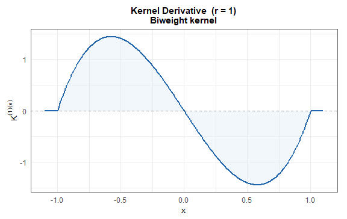

```r
plot(kf)
```

`kernel.conv()` returns $K^{(r)} * K^{(r)}$ (class `kconv`), the building block of the cross-validation criteria. At $0$ it equals $(-1)^r R(K^{(r)})$:

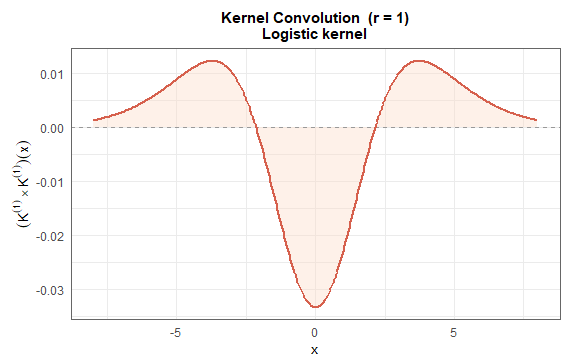

```r
kc <- kernel.conv(kernel = "logistic", deriv.order = 1L)
plot(kc)
```

```r
kernel.conv(x = 0, kernel = "logistic", deriv.order = 1L)@y   # -R(K') = -1/30
```

```
#> [1] -0.03333333
```

The constants used by the selectors, $\mu_2(K)$, $\mu_4(K)$ and $R(K^{(r)})$, are available from the low-level routine `Cpp_kernel_constants()`:

```r
kers <- c("gaussian", "epanechnikov", "uniform", "triangular", "biweight",
          "triweight", "tricube", "cosine", "silverman", "logistic",
          "pow(2,4)", "pow(1.5,2.5)")
round(t(sapply(kers, function(k) Cpp_kernel_constants(k, 0L)[c("mu2", "mu4", "R")])), 5)
```

```
#>                  mu2       mu4       R
#> gaussian     1.00000   3.00000 0.28209
#> epanechnikov 0.20000   0.08571 0.60000
#> uniform      0.33333   0.20000 0.50000
#> triangular   0.16667   0.06667 0.66667
#> biweight     0.14286   0.04762 0.71429
#> triweight    0.11111   0.03030 0.81585
#> tricube      0.14403   0.04545 0.70850
#> cosine       0.18943   0.07872 0.61685
#> silverman    0.00000 -24.00000 0.26517
#> logistic     3.28987  45.45758 0.16667
#> pow(2,4)     0.09091   0.02098 0.90703
#> pow(1.5,2.5) 0.10477   0.02885 0.85302
```

The Silverman kernel is of order 4 ($\mu_2 = 0$, $\mu_4 < 0$); all the others are second-order kernels.

### 2.2 The power family Pow(s,t)

For $s > 0$ and $t \ge 0$,
$$K_{s,t}(x) = c_{s,t}\,(1 - \lvert x\rvert^s)^t\, \mathbf 1_{\lvert
x\rvert \le 1},
\qquad c_{s,t} = \frac{s}{2\,B(1/s,\, t+1)},$$
is passed as the string `"pow(s,t)"`, or built with `kernel.pow(s, t)`. It contains uniform (`pow(s,0)`), triangular (`pow(1,1)`), Epanechnikov (`pow(2,1)`), biweight (`pow(2,2)`), triweight (`pow(2,3)`) and tricube (`pow(3,3)`). Its constants are exact: $\mu_k(K) = B\big(\tfrac{k+1}{s}, t+1\big) / B\big(\tfrac1s, t+1\big)$ and $R(K) = s\,B(1/s, 2t+1) / \big(2\,B(1/s, t+1)^2\big)$.

```r
kernel.pow(2, 3)
```

```
#> [1] "pow(2,3)"
```

```r
all.equal(kernel.fun(kernel = "pow(2,2)")@y, kernel.fun(kernel = "biweight")@y)
```

```
#> [1] TRUE
```

```r
Cpp_kernel_constants(kernel.pow(1.5, 2.5), 0L)
```

```
#>          c        mu2        mu4          R
#> 1.23761742 0.10477184 0.02885017 0.85302293
```

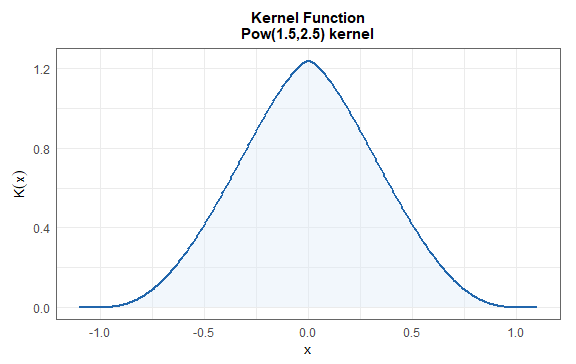

```r
plot(kernel.fun(kernel = kernel.pow(1.5, 2.5)))
```

Increasing $t$ (or decreasing $s$) concentrates the kernel around $0$:

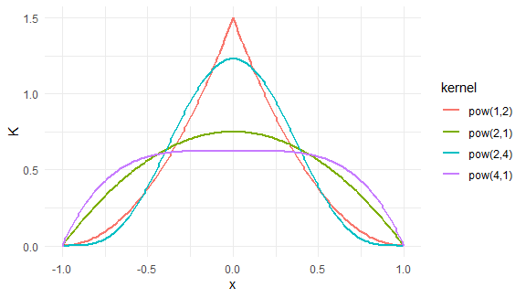

```r
grid <- seq(-1, 1, length.out = 201)
shapes <- do.call(rbind, lapply(c("pow(2,1)", "pow(2,4)", "pow(4,1)", "pow(1,2)"),
  function(k) data.frame(x = grid, K = Cpp_kernel_deriv(k, grid, 0L), kernel = k)))
ggplot2::ggplot(shapes, ggplot2::aes(x, K, colour = kernel)) +
  ggplot2::geom_line(linewidth = 0.9) + ggplot2::theme_minimal()
```

## 3. Estimating a density and its derivatives

We use a bimodal sample whose true density is known, $f = 0.6\,N(-1, 0.5^2) + 0.4\,N(1.5, 0.7^2)$:

```r
set.seed(2027)
n <- 300
x <- c(rnorm(0.6 * n, -1, 0.5), rnorm(0.4 * n, 1.5, 0.7))
f_true <- function(t, r = 0L) {
  comp <- function(m, s) {
    z  <- (t - m) / s
    He <- switch(r + 1L, 1, z, z^2 - 1)        # Hermite polynomials
    (-1)^r * He * dnorm(z) / s^(r + 1)
  }
  0.6 * comp(-1, 0.5) + 0.4 * comp(1.5, 0.7)
}
```

`dkde()` computes $\hat f_h^{(r)}$ (class `dkde`). When `h` is missing, the UCV bandwidth is used.

```r
f0 <- dkde(data = x)
f0
```

```
#>
#> Kernel density estimate
#> Kernel     : gaussian
#> Bandwidth h: 0.234919
#> n          : 300
#> Grid points: 512
```

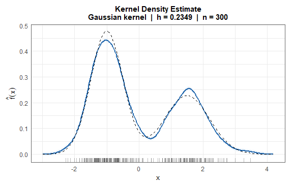

```r
p <- quiet(plot(f0))
p + ggplot2::stat_function(fun = f_true, linetype = "dashed")
```

The first derivative, estimated with its own (SCV) bandwidth (dashed: true $f'$):

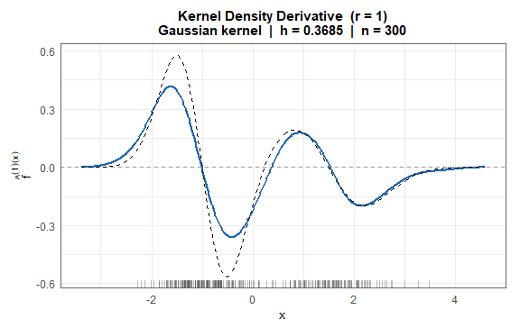

```r
h1 <- h.scv(x, deriv.order = 1L)
p1 <- quiet(plot(dkde(data = x, h = h1@h, deriv.order = 1L)))
p1 + ggplot2::stat_function(fun = f_true, args = list(r = 1L), linetype = "dashed")
```

Compare with the density bandwidth, which is too small for $f'$:

```r
c(h_density = f0@h, h_derivative = h1@h)
```

```
#>    h_density h_derivative
#>    0.2349190    0.3684841
```

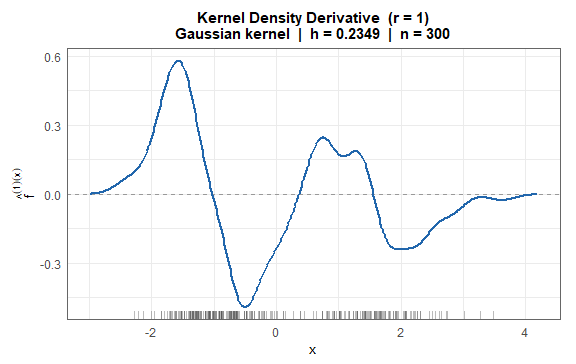

```r
plot(dkde(data = x, h = f0@h, deriv.order = 1L), band = FALSE)
```

Every kernel can be used, each with its own bandwidth. Here the Gaussian, logistic and power `pow(2,4)` kernels with UCV bandwidths, against the true density (dashed):

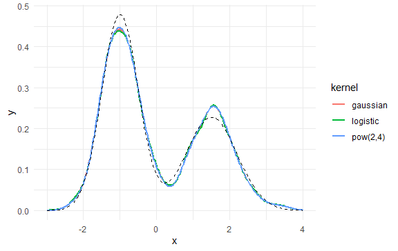

```r
grid <- seq(-3, 4, length.out = 300)
est <- do.call(rbind, lapply(c("gaussian", "logistic", "pow(2,4)"), function(k) {
  d <- dkde(x = grid, data = x, h = h.ucv(x, kernel = k)@h, kernel = k)
  data.frame(x = d@x, y = d@y, kernel = k)
}))
ggplot2::ggplot(est, ggplot2::aes(x, y, colour = kernel)) +
  ggplot2::geom_line(linewidth = 0.8) +
  ggplot2::stat_function(fun = f_true, colour = "black", linetype = "dashed") +
  ggplot2::theme_minimal()
```

## 4. Bandwidth selectors

All selectors return an object of class `bandwidth` (slots `h`, `min.obj`, `hos`, `method`, …, and for PCV `criterion` and `groups`). Writing $\psi_h(u) = u/h$ for the scaled differences $X_j - X_i$, the criteria minimised are:

- **AMISE** (`h.amise`) — closed-form rule with a normal reference $\hat h = \hat\sigma\,\Big[\frac{243(2r+1)R(K^{(r)})}{35\,\mu_2(K)^2\,n}\Big]^{1/(2r+5)}$ (the over-smoothing bandwidth $h_{os}$ used to bound all searches).
- **UCV** (`h.ucv`) — unbiased / least-squares cross-validation, $\mathrm{UCV}(h) = \frac{R(K^{(r)})}{nh^{2r+1}} + \frac{(-1)^r}{n(n-1)h^{2r+1}} \sum_{i\ne j}\big(K^{(r)}*K^{(r)} - 2K^{(2r)}\big)\Big(\frac{X_j-X_i}{h}\Big)$.
- **BCV** (`h.bcv`) — biased cross-validation, which estimates $R(f^{(r+2)})$ in the AMISE either with $K^{(r+2)}*K^{(r+2)}$ (BCV1) or with $K^{(2r+4)}$ (BCV2).
- **CCV** (`h.ccv`) — complete cross-validation (higher-order bias correction).
- **MCV** (`h.mcv`) — modified cross-validation.
- **TCV** (`h.tcv`) — trimmed cross-validation (pairs closer than $1/(nh^{2r+1})$ are discarded in the $K^{(2r)}$ term).
- **SCV** (`h.scv`) — smoothed cross-validation (Gaussian kernel): the squared bias is estimated from a Gaussian pilot $\tilde f_g$, which gives a closed form in terms of $\phi^{(2r)}$ for any $r$.
- **PCV** (`h.pcv`) — partitioned cross-validation (Marron, 1987): the sample is partitioned at random into `m` subsamples, a score (`criterion = "UCV"` by default, or TCV, MCV, CCV, BCV1, BCV2) is computed in each subsample at the bandwidth $h\,m^{1/(2r+5)}$ suited to its size, and $h$ minimises the average; the across-sample variability is reduced and the cost divided by about `m`; with `nrep > 1` the score is also averaged over `nrep` random partitions.
- **MLCV** (`h.mlcv`) — maximum-likelihood (leave-one-out) cross-validation, density only.

```r
bw <- h.ucv(x)
bw
```

```
#>
#> Call: UCV bandwidth selector
#> Kernel      : gaussian
#> Deriv. order: 0
#> Bandwidth  h: 0.234919
#> Objective   : -0.277091
#> h_os        : 0.495297
```

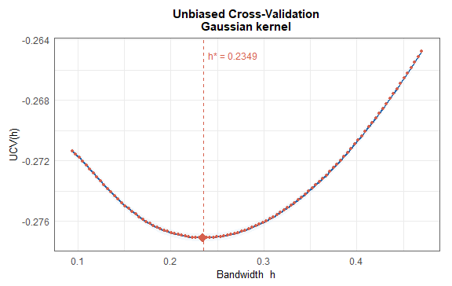

```r
plot(bw)
```

`lines()` returns a ggplot2 layer, so several criteria can be drawn together:

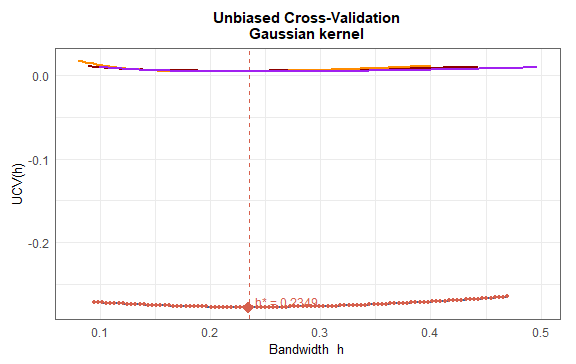

```r
p <- quiet(plot(h.ucv(x)))
p$plot +
  lines(h.bcv(x), color = "darkred") +
  lines(h.ccv(x), color = "darkorange") +
  lines(h.mcv(x), color = "purple")
```

### 4.1 Comparison on the bimodal sample

The integrated squared error $\mathrm{ISE}(h) = \int (\hat f_h^{(r)} - f^{(r)})^2$ measures the quality of each selected bandwidth:

```r
ise <- function(h, r) {
  d <- dkde(x = seq(-4, 5, length.out = 400), data = x, h = h, deriv.order = r)
  sum((d@y - f_true(d@x, r))^2) * diff(d@x[1:2])
}
sel <- list(AMISE = h.amise, UCV = h.ucv, BCV1 = h.bcv,
            BCV2 = function(x, ...) h.bcv(x, whichbcv = 2, ...),
            CCV = h.ccv, MCV = h.mcv, TCV = h.tcv, SCV = h.scv,
            PCV = function(x, ...) h.pcv(x, m = 2, nrep = 5, ...))
# reproducible random partitions of PCV (UCV in 2 subsamples, 5 partitions)
set.seed(1)
tab <- sapply(0:1, function(r) {
  h <- sapply(sel, function(f) f(x, deriv.order = r)@h)
  c(rbind(h = h, ISE = sapply(h, ise, r = r)))
})
dimnames(tab) <- list(paste(rep(names(sel), each = 2), c("h", "ISE")),
                      c("r = 0", "r = 1"))
round(tab, 4)
```

[output not shown]

```r
c(MLCV = h.mlcv(x)@h)   # density only
```

```
#>      MLCV
#> 0.2371343
```

Two well-known behaviours show up in such comparisons:

### 4.2 Same criterion, different kernels

Bandwidths are not comparable across kernels: each kernel has its own scale ($\mu_2(K)$, $R(K)$). The selectors take this into account:

```r
ks <- c("gaussian", "epanechnikov", "uniform", "triangular", "biweight", "triweight",
        "tricube", "cosine", "silverman", "logistic", "pow(2,4)", "pow(1.5,2.5)")
round(sapply(ks, function(k) h.ucv(x, kernel = k)@h), 4)
```

```
#>     gaussian epanechnikov      uniform   triangular     biweight    triweight
#>       0.2349       0.5148       0.4179       0.5247       0.5685       0.6513
#>      tricube       cosine    silverman     logistic     pow(2,4) pow(1.5,2.5)
#>       0.5813       0.5177       0.2321       0.1347       0.7466       0.6850
```

## 5. Example datasets

The package contains five samples of size 200 from the Marron and Wand (1992) normal mixtures (`?"kedd-data"`): `kurtotic` (#4), `outlier` (#5), `bimodal` (#7, separated bimodal), `trimodal` (#9) and `claw` (#10). Their true densities are known, which makes them convenient benchmarks. The claw density, for instance, is hard to estimate: the five narrow peaks need a small bandwidth.

```r
f_claw <- function(x) 0.5 * dnorm(x) +
  rowSums(sapply(0:4, function(l) 0.1 * dnorm(x, l / 2 - 1, 0.1)))
set.seed(1)
bw_claw <- sapply(list(UCV = h.ucv, BCV1 = h.bcv, MCV = h.mcv, SCV = h.scv,
                       PCV = function(s) h.pcv(s, m = 2, nrep = 5), AMISE = h.amise),
                  function(f) suppressWarnings(f(claw))@h)
round(bw_claw, 4)
```

```
#>    UCV   BCV1    MCV    SCV    PCV  AMISE
#> 0.0588 0.3744 0.3922 0.3315 0.0733 0.3158
```

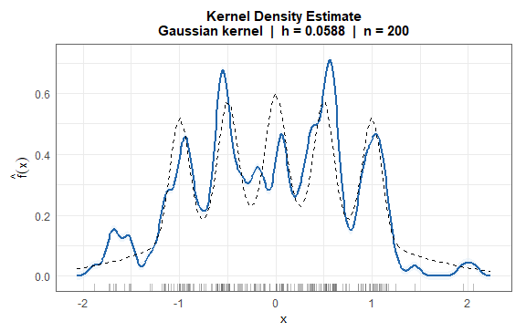

```r
p <- quiet(plot(dkde(data = claw, h = bw_claw[["UCV"]])))
p + ggplot2::stat_function(fun = f_claw, linetype = "dashed")
```

The same selectors on the five samples:

```r
samples <- list(kurtotic = kurtotic, outlier = outlier, bimodal = bimodal,
                trimodal = trimodal, claw = claw)
set.seed(1)
round(sapply(samples, function(s)
  sapply(list(AMISE = h.amise, UCV = h.ucv, BCV1 = h.bcv, MCV = h.mcv, SCV = h.scv,
              PCV = function(s) h.pcv(s, m = 2, nrep = 5)),
         function(f) suppressWarnings(f(s))@h)), 4)
```

```
#>       kurtotic outlier bimodal trimodal   claw
#> AMISE   0.3530  0.0795  0.6443   0.4814 0.3158
#> UCV     0.0524  0.0332  0.2103   0.1003 0.0588
#> BCV1    0.6189  0.0356  0.2246   0.4359 0.3744
#> MCV     0.7061  0.0377  0.2402   0.5001 0.3922
#> SCV     0.2445  0.0492  0.3656   0.4695 0.3315
#> PCV     0.0576  0.0332  0.2193   0.4022 0.0739
```

## 6. Parallel computation

The $O(n^2)$ criteria (sums over all pairs $X_i, X_j$) are computed in C++ and split between the processor cores with OpenMP. The argument `nthreads` of every selector and of `dkde()` sets the number of threads **of that call**:

- `nthreads = 0` (default): all processors;
- `nthreads = k > 0`: `k` threads (`1` = sequential);
- both are capped by the environment variable `OMP_THREAD_LIMIT`, and a call never changes the threads used by later calls.

`Cpp_omp_threads()` reports how many threads a call actually gets. The results do not depend on `nthreads`, only the computing time does:

```r
c(all = Cpp_omp_threads(0L), two = Cpp_omp_threads(2L))
```

```
#> all two
#>   2   2
```

```r
y <- rnorm(1500)
system.time(h_seq <- h.ucv(y, nthreads = 1L)@h)
```

```
#> utilisateur     système      écoulé
#>        1.06        0.00        1.08
```

```r
system.time(h_par <- h.ucv(y, nthreads = 0L)@h)
```

```
#> utilisateur     système      écoulé
#>        1.21        0.00        0.84
```

```r
all.equal(h_seq, h_par)
```

```
#> [1] TRUE
```

## 7. Summary of functions

| function | purpose | returns |
| --- | --- | --- |
| `kernel.fun(x, deriv.order, kernel, n.grid)` | $K^{(r)}(x)$ | `kfun` |
| `kernel.conv(x, deriv.order, kernel, n.grid)` | $(K^{(r)} * K^{(r)})(x)$ | `kconv` |
| `kernel.pow(s, t)` | name of a Pow(s,t) kernel | character |
| `dkde(x, data, h, deriv.order, kernel, nthreads)` | $\hat f_h^{(r)}(x)$ | `dkde` |
| `h.amise(x, deriv.order, kernel)` | AMISE rule | `bandwidth` |
| `h.ucv`, `h.bcv`, `h.ccv`, `h.mcv`, `h.tcv`, `h.scv` `(x, deriv.order, kernel, lower, upper, tol, nthreads)` | cross-validation selectors | `bandwidth` |
| `h.pcv(x, m, criterion, nrep, deriv.order, kernel, lower, upper, tol, nthreads)` | partitioned CV | `bandwidth` |
| `h.mlcv(x, kernel, lower, upper, tol, nthreads)` | likelihood CV (density) | `bandwidth` |
| `show()`, `plot()` | print / ggplot2 figure | — |
| `lines(<bandwidth>)` | criterion curve as a ggplot2 layer | layer |
| `kurtotic`, `outlier`, `bimodal`, `trimodal`, `claw` | example samples | numeric |
| `Cpp_kernel_constants()`, `Cpp_omp_threads()`, `Cpp_*()` | low-level C++ routines (`?"kedd-lowlevel"`) | numeric |

## 8. Resources

- Demonstrations: `demo(package = "kedd")` (`kedd`, `kernels`, `bandwidths`).
- Two-page cheatsheet and source code: https://github.com/ac-guidoum/kedd.
- Bug reports and suggestions: https://github.com/ac-guidoum/kedd/issues.
- Citation: `citation("kedd")`.

## References

- Bowman, A. (1984). An alternative method of cross-validation for the smoothing of density estimates. *Biometrika*, 71, 353–360.
- Duin, R. P. W. (1976). On the choice of smoothing parameters for Parzen estimators of probability density functions. *IEEE Transactions on Computers*, C-25, 1175–1179.
- Feluch, W. and Koronacki, J. (1992). A note on modified cross-validation in density estimation. *Computational Statistics and Data Analysis*, 13, 143–151.
- Guidoum, A. C. (2020). Kernel estimator and bandwidth selection for density and its derivatives: the kedd package. arXiv:2012.06102.
- Habbema, J. D. F., Hermans, J. and Van den Broek, K. (1974). A stepwise discrimination analysis program using density estimation. *Compstat 1974*, Physica Verlag, Vienna.
- Hall, P., Marron, J. S. and Park, B. U. (1992). Smoothed cross-validation. *Probability Theory and Related Fields*, 92, 1–20.
- Jones, M. C. and Kappenman, R. F. (1992). On a class of kernel density estimate bandwidth selectors. *Scandinavian Journal of Statistics*, 19, 337–349.
- Marron, J. S. (1987). Partitioned cross-validation. *Econometric Reviews*, 6, 271–283.
- Marron, J. S. and Wand, M. P. (1992). Exact mean integrated squared error. *The Annals of Statistics*, 20, 712–736.
- Rudemo, M. (1982). Empirical choice of histograms and kernel density estimators. *Scandinavian Journal of Statistics*, 9, 65–78.
- Scott, D. W. and Terrell, G. R. (1987). Biased and unbiased cross-validation in density estimation. *JASA*, 82, 1131–1146.
- Stute, W. (1992). Modified cross-validation in density estimation. *Journal of Statistical Planning and Inference*, 30, 293–305.
- Wand, M. P. and Jones, M. C. (1995). *Kernel Smoothing*. Chapman & Hall.
- Härdle, W., Marron, J. S. and Wand, M. P. (1990). Bandwidth choice for density derivatives. *JRSS B*, 52, 223–232.